# **Homework 3**

# MIMUW XAI WINTER 2022/2023

# Task

In this homework we used brain stroke dataset from kaggle.

### Ad. 0

I prepared the data (onehot encoding) and first trained XGBClassifier model.The model achieved 94,6% accuracy.

### Ad. 1

I selected some observations. All predictions were 0.

### Ad. 2

Calculated decomposition. The results are as follows

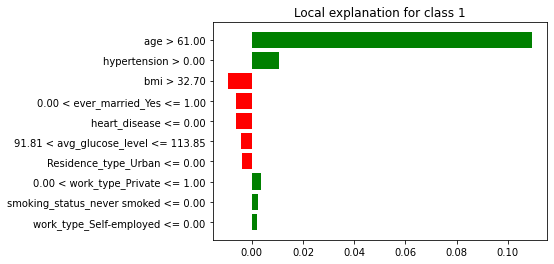

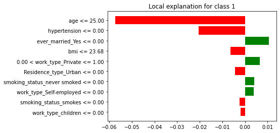

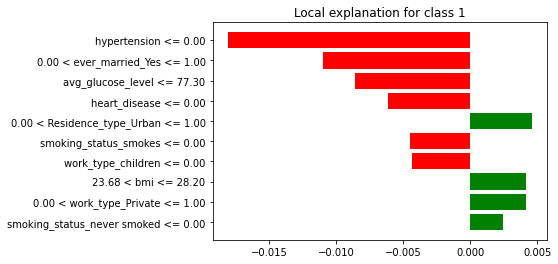

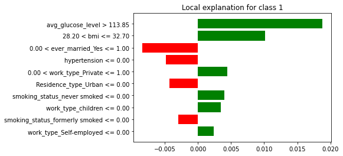

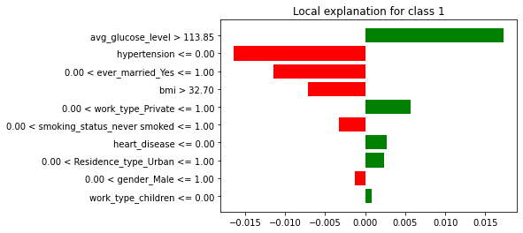

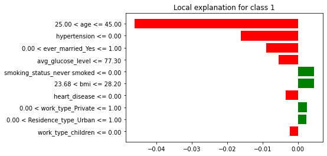

Results from these random samples are unstable:

3/6 samples have *age* as a highest attribute and its consistant with result from previous homework

2/6 samples looks first for *avg_glucose_level*

1/6 smaples starts with *hypertension*

## Ad. 4

From shap I got following results:

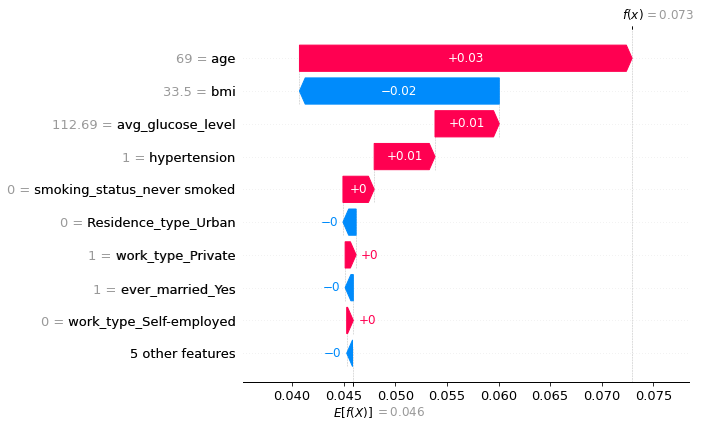

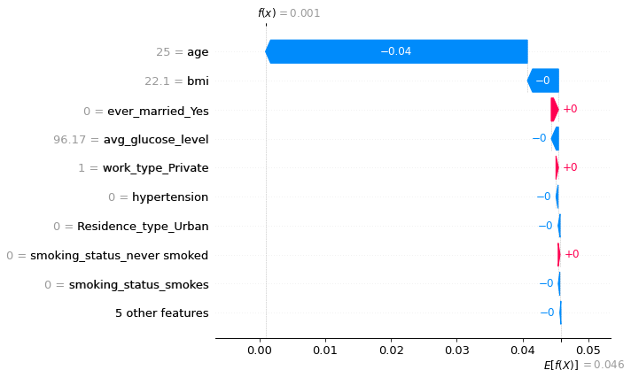

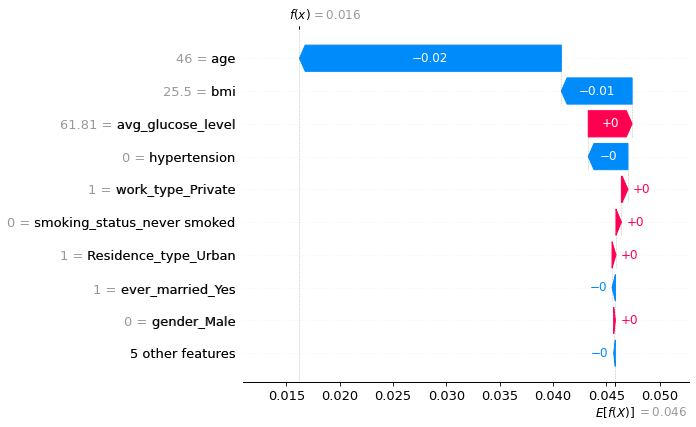

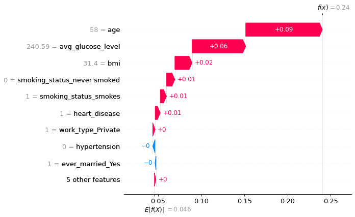

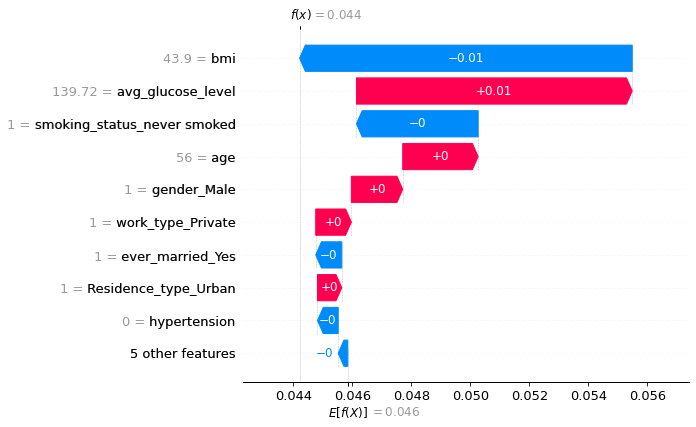

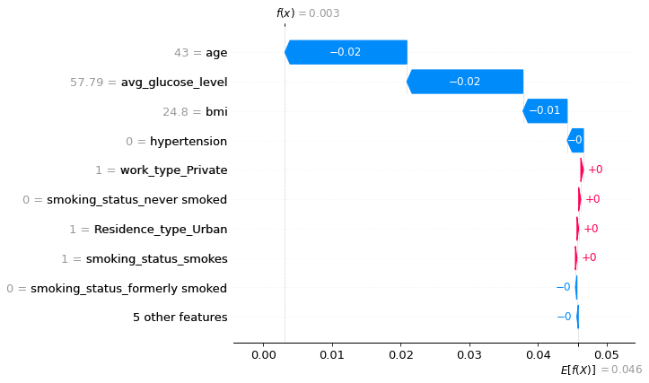

These results differ from these got from lime. Here we observe age as highest attribute in 5 out of 6 cases. Although avg_glucose_level is at the second place or third place in almost every sample.

## Ad. 5 Comparing with different models:

I checked results for CatBoostClassifier and for LogisticRegression.

## Ad. 6

Lime in compare to shap gives very different results. I expected that lime would give similar most important attribute. In ecomposition of one of samples (pictures below) we can see that age is not even among top 10 attributes in lime, but it is the highest in shap, so i am very surprised. Maybe *age* in the corresponding lime bucket is just not significant. It actually makes sense because we don't often hear about a man having a stroke at a young age, but more often we hear about older people who have had a stroke. When predicting brain stroke for middle age people, health condition indicators are simply more significant attributes.

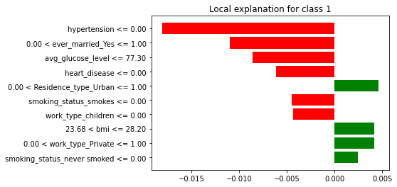

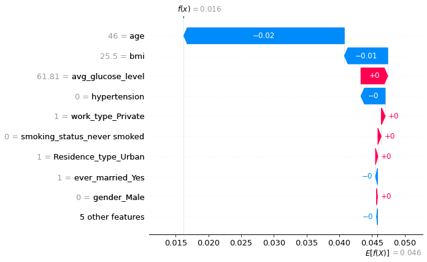

# Appendix

## 0. Setup

```python
!pip install dalex shap catboost lime
```

```python
from sklearn.linear_model import LogisticRegression
from sklearn.preprocessing import OneHotEncoder
from sklearn.metrics import accuracy_score
from sklearn.model_selection import train_test_split
from sklearn.ensemble import RandomForestClassifier
from xgboost import XGBClassifier
import pandas as pd
import lime

import dalex as dx
import shap
```

```python
df = pd.read_csv("brain_stroke.csv")
df
```

|  | gender | age | hypertension | heart_disease | ever_married | work_type | Residence_type | avg_glucose_level | bmi | smoking_status | stroke |
| --- | --- | --- | --- | --- | --- | --- | --- | --- | --- | --- | --- |
| 0 | Male | 67.0 | 0 | 1 | Yes | Private | Urban | 228.69 | 36.6 | formerly smoked | 1 |
| 1 | Male | 80.0 | 0 | 1 | Yes | Private | Rural | 105.92 | 32.5 | never smoked | 1 |
| 2 | Female | 49.0 | 0 | 0 | Yes | Private | Urban | 171.23 | 34.4 | smokes | 1 |
| 3 | Female | 79.0 | 1 | 0 | Yes | Self-employed | Rural | 174.12 | 24.0 | never smoked | 1 |
| 4 | Male | 81.0 | 0 | 0 | Yes | Private | Urban | 186.21 | 29.0 | formerly smoked | 1 |
| ... | ... | ... | ... | ... | ... | ... | ... | ... | ... | ... | ... |
| 4976 | Male | 41.0 | 0 | 0 | No | Private | Rural | 70.15 | 29.8 | formerly smoked | 0 |
| 4977 | Male | 40.0 | 0 | 0 | Yes | Private | Urban | 191.15 | 31.1 | smokes | 0 |
| 4978 | Female | 45.0 | 1 | 0 | Yes | Govt_job | Rural | 95.02 | 31.8 | smokes | 0 |
| 4979 | Male | 40.0 | 0 | 0 | Yes | Private | Rural | 83.94 | 30.0 | smokes | 0 |
| 4980 | Female | 80.0 | 1 | 0 | Yes | Private | Urban | 83.75 | 29.1 | never smoked | 0 |

4981 rows × 11 columns

Dataset consists of features that are nonnumerical. Let's hot encode them first.

```python
from sklearn.preprocessing import OneHotEncoder
from sklearn.compose import make_column_transformer


df_one_hot = pd.get_dummies(df, drop_first = True)
df_one_hot
```

|  | age | hypertension | heart_disease | avg_glucose_level | bmi | stroke | gender_Male | ever_married_Yes | work_type_Private | work_type_Self-employed | work_type_children | Residence_type_Urban | smoking_status_formerly smoked | smoking_status_never smoked | smoking_status_smokes |
| --- | --- | --- | --- | --- | --- | --- | --- | --- | --- | --- | --- | --- | --- | --- | --- |
| 0 | 67.0 | 0 | 1 | 228.69 | 36.6 | 1 | 1 | 1 | 1 | 0 | 0 | 1 | 1 | 0 | 0 |
| 1 | 80.0 | 0 | 1 | 105.92 | 32.5 | 1 | 1 | 1 | 1 | 0 | 0 | 0 | 0 | 1 | 0 |
| 2 | 49.0 | 0 | 0 | 171.23 | 34.4 | 1 | 0 | 1 | 1 | 0 | 0 | 1 | 0 | 0 | 1 |
| 3 | 79.0 | 1 | 0 | 174.12 | 24.0 | 1 | 0 | 1 | 0 | 1 | 0 | 0 | 0 | 1 | 0 |
| 4 | 81.0 | 0 | 0 | 186.21 | 29.0 | 1 | 1 | 1 | 1 | 0 | 0 | 1 | 1 | 0 | 0 |
| ... | ... | ... | ... | ... | ... | ... | ... | ... | ... | ... | ... | ... | ... | ... | ... |
| 4976 | 41.0 | 0 | 0 | 70.15 | 29.8 | 0 | 1 | 0 | 1 | 0 | 0 | 0 | 1 | 0 | 0 |
| 4977 | 40.0 | 0 | 0 | 191.15 | 31.1 | 0 | 1 | 1 | 1 | 0 | 0 | 1 | 0 | 0 | 1 |
| 4978 | 45.0 | 1 | 0 | 95.02 | 31.8 | 0 | 0 | 1 | 0 | 0 | 0 | 0 | 0 | 0 | 1 |
| 4979 | 40.0 | 0 | 0 | 83.94 | 30.0 | 0 | 1 | 1 | 1 | 0 | 0 | 0 | 0 | 0 | 1 |
| 4980 | 80.0 | 1 | 0 | 83.75 | 29.1 | 0 | 0 | 1 | 1 | 0 | 0 | 1 | 0 | 1 | 0 |

4981 rows × 15 columns

Preparing train and test samples.

```python
X = df_one_hot.drop("stroke", axis=1)
y = df_one_hot.stroke
X_train, X_test, y_train, y_test =train_test_split( X, y, test_size=0.2, random_state=42)
```

```python
X_train
```

|  | age | hypertension | heart_disease | avg_glucose_level | bmi | gender_Male | ever_married_Yes | work_type_Private | work_type_Self-employed | work_type_children | Residence_type_Urban | smoking_status_formerly smoked | smoking_status_never smoked | smoking_status_smokes |
| --- | --- | --- | --- | --- | --- | --- | --- | --- | --- | --- | --- | --- | --- | --- |
| 1652 | 26.00 | 0 | 0 | 168.15 | 22.9 | 0 | 0 | 1 | 0 | 0 | 1 | 0 | 1 | 0 |
| 1609 | 27.00 | 0 | 0 | 80.57 | 39.8 | 0 | 1 | 1 | 0 | 0 | 1 | 0 | 0 | 1 |
| 166 | 54.00 | 0 | 0 | 87.85 | 31.1 | 1 | 1 | 0 | 0 | 0 | 0 | 0 | 0 | 1 |
| 2488 | 2.00 | 0 | 0 | 92.30 | 14.8 | 0 | 0 | 0 | 0 | 1 | 0 | 0 | 0 | 0 |
| 3337 | 69.00 | 1 | 0 | 112.69 | 33.5 | 0 | 1 | 1 | 0 | 0 | 0 | 1 | 0 | 0 |
| ... | ... | ... | ... | ... | ... | ... | ... | ... | ... | ... | ... | ... | ... | ... |
| 4426 | 54.00 | 0 | 0 | 231.54 | 29.9 | 0 | 1 | 0 | 0 | 0 | 1 | 0 | 1 | 0 |
| 466 | 38.00 | 0 | 0 | 70.92 | 41.6 | 0 | 1 | 0 | 0 | 0 | 1 | 0 | 1 | 0 |
| 3092 | 13.00 | 0 | 0 | 90.60 | 16.9 | 1 | 0 | 1 | 0 | 0 | 0 | 0 | 1 | 0 |
| 3772 | 0.48 | 0 | 0 | 118.75 | 17.4 | 0 | 0 | 0 | 0 | 1 | 0 | 0 | 0 | 0 |
| 860 | 57.00 | 0 | 0 | 128.28 | 34.2 | 0 | 1 | 0 | 1 | 0 | 0 | 0 | 1 | 0 |

3984 rows × 14 columns

## 1. Calculating the predictions for some selected observations

### 1.1 Training XGBoost classifier model

```python
xgb=XGBClassifier()
xgb.fit(X_train,y_train)
xgb_predict=xgb.predict(X_test)
xgb_acc=accuracy_score(xgb_predict,y_test)
model = xgb
xgb_acc
```

```
0.9458375125376128
```

The model achieved 94,6% accuracy.

### 1.2 Calculating the predictions

```python
observations = [4, 8, 15, 16, 34, 42]
predictions = model.predict(X_train.iloc[observations])
predictions
```

```
array([0, 0, 0, 0, 0, 0])
```

## 2. Calculating the decomposition of these predictions with lime

```python
explainer = dx.Explainer(model, X_train, y_train)
```

```
Preparation of a new explainer is initiated

  -> data              : 3984 rows 14 cols
  -> target variable   : Parameter 'y' was a pandas.Series. Converted to a numpy.ndarray.
  -> target variable   : 3984 values
  -> model_class       : xgboost.sklearn.XGBClassifier (default)
  -> label             : Not specified, model's class short name will be used. (default)
  -> predict function  : <function yhat_proba_default at 0x7f1c8795bdd0> will be used (default)
  -> predict function  : Accepts only pandas.DataFrame, numpy.ndarray causes problems.
  -> predicted values  : min = 0.000722, mean = 0.0487, max = 0.481
  -> model type        : classification will be used (default)
  -> residual function : difference between y and yhat (default)
  -> residuals         : min = -0.349, mean = 4.35e-06, max = 0.986
  -> model_info        : package xgboost

A new explainer has been created!
```

```python
explainer.model_performance(cutoff=y_train.mean())
```

|  | recall | precision | f1 | accuracy | auc |
| --- | --- | --- | --- | --- | --- |
| XGBClassifier | 0.927835 | 0.14658 | 0.253165 | 0.733434 | 0.913604 |

```python
observations_data = X_train.iloc[observations]
explainer.predict(observations_data)
```

```
array([0.07293652, 0.00089618, 0.01622023, 0.24037567, 0.04421299,
       0.00316113], dtype=float32)
```

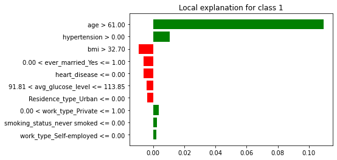

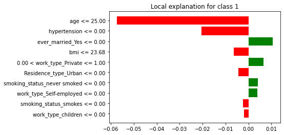

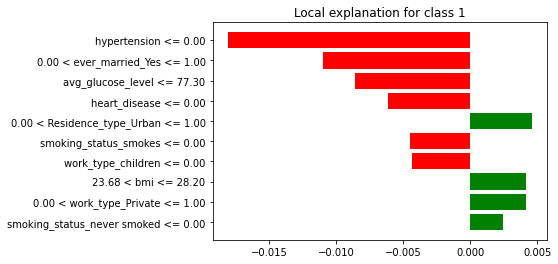

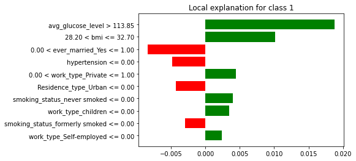

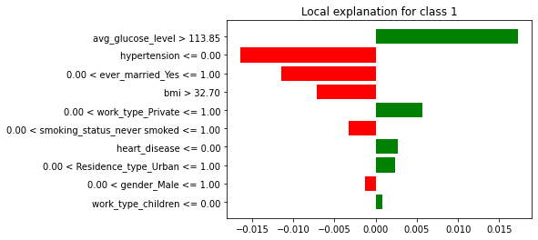

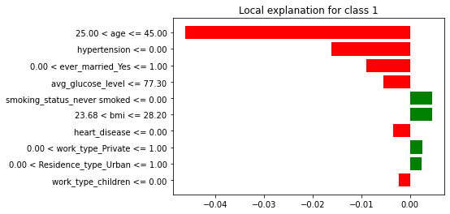

```python
for i in range(observations_data.shape[0]):
  explanation = explainer.predict_surrogate(observations_data.iloc[[i]])
  explanation.plot()
```

### 4. Decomposition using shap

```python
shap_explainer = shap.explainers.Tree(model, data=X_train, model_output="probability")
```

```python
shap_values = shap_explainer(X_train)
shap_values
```

[output not shown]

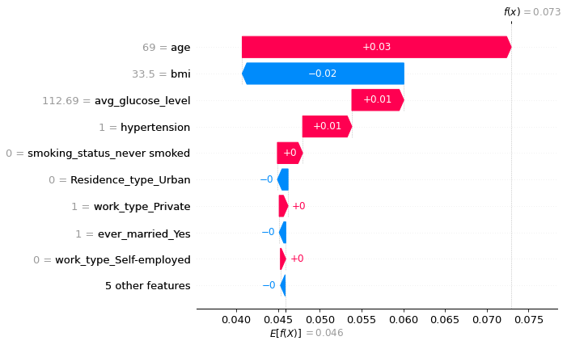

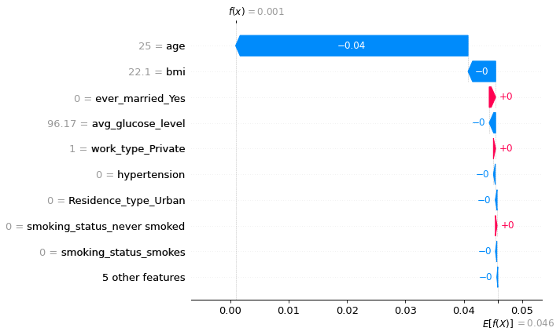

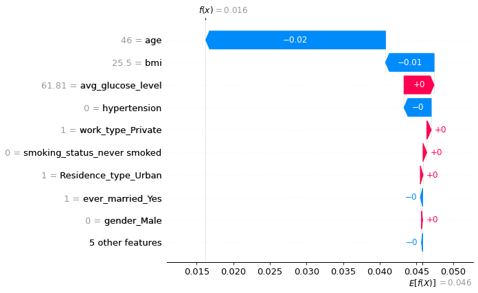

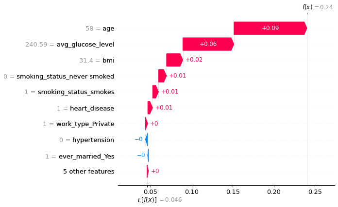

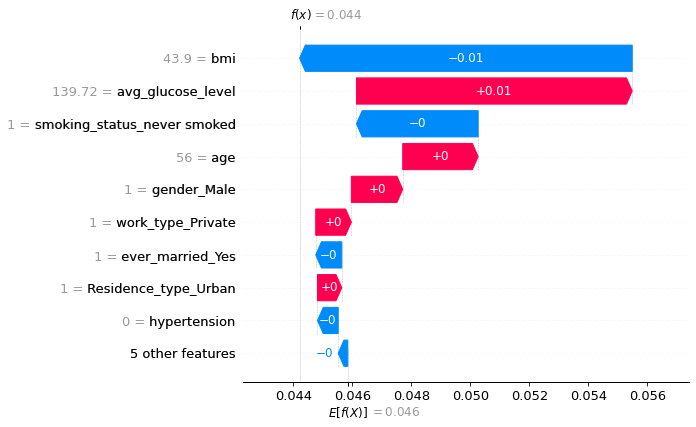

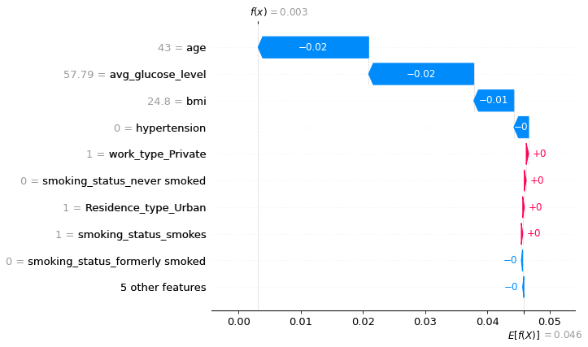

```python
for i in observations:
    shap.plots.waterfall(shap_values[i])
```

## 5. Trying with different model

### 5.1 CatBoostClassifier

```python
from catboost import CatBoostClassifier
cat=CatBoostClassifier()
cat.fit(X_train,y_train)
cat_predict=xgb.predict(X_test)
cat_acc=accuracy_score(xgb_predict,y_test)
model = cat
cat_acc
```

[output not shown]

[output cut: 946 more lines]

[output not shown]

```
0.9458375125376128
```

```python
explainer = dx.Explainer(model, X_train, y_train)
```

```
Preparation of a new explainer is initiated

  -> data              : 3984 rows 14 cols
  -> target variable   : Parameter 'y' was a pandas.Series. Converted to a numpy.ndarray.
  -> target variable   : 3984 values
  -> model_class       : catboost.core.CatBoostClassifier (default)
  -> label             : Not specified, model's class short name will be used. (default)
  -> predict function  : <function yhat_proba_default at 0x7f1c8795bdd0> will be used (default)
  -> predict function  : Accepts pandas.DataFrame and numpy.ndarray.
  -> predicted values  : min = 2.67e-05, mean = 0.0483, max = 0.906
  -> model type        : classification will be used (default)
  -> residual function : difference between y and yhat (default)
  -> residuals         : min = -0.334, mean = 0.000411, max = 0.985
  -> model_info        : package catboost

A new explainer has been created!
```

```python
explainer.model_performance(cutoff=y_train.mean())
```

|  | recall | precision | f1 | accuracy | auc |
| --- | --- | --- | --- | --- | --- |
| CatBoostClassifier | 0.979381 | 0.218642 | 0.357479 | 0.828564 | 0.988756 |

```python
observations_data = X_train.iloc[observations]
explainer.predict(observations_data)
```

```
array([3.28457105e-02, 4.78056357e-04, 5.92971741e-03, 7.28642799e-01,
       3.84354418e-02, 1.96248092e-03])
```

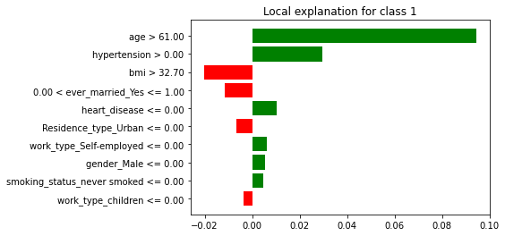

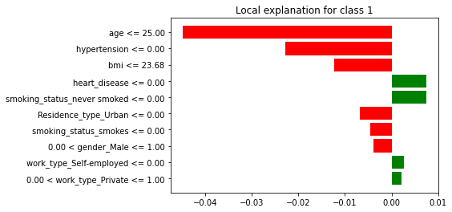

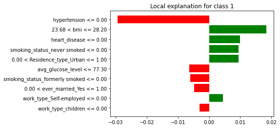

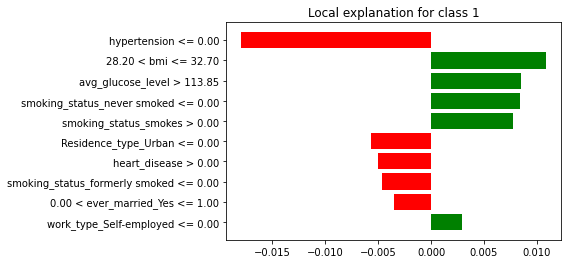

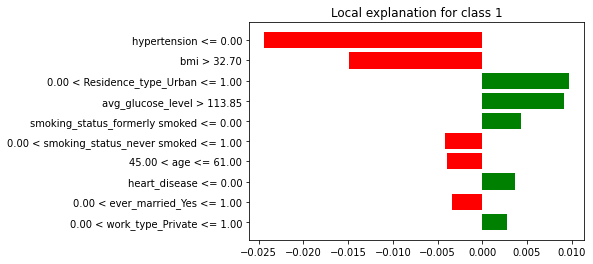

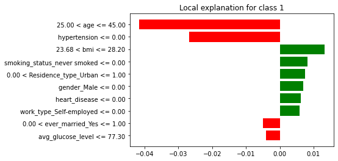

```python
for i in range(observations_data.shape[0]):
  explanation = explainer.predict_surrogate(observations_data.iloc[[i]])
  explanation.plot()
```

### 5.2 LogisticRegression

```python
clf=LogisticRegression()
clf.fit(X_train,y_train)
clf_predict=xgb.predict(X_test)
clf_acc=accuracy_score(clf_predict,y_test)
model = clf
clf_acc
```

```
lbfgs failed to converge (status=1):
STOP: TOTAL NO. of ITERATIONS REACHED LIMIT.

Increase the number of iterations (max_iter) or scale the data as shown in:
    https://scikit-learn.org/stable/modules/preprocessing.html
Please also refer to the documentation for alternative solver options:
    https://scikit-learn.org/stable/modules/linear_model.html#logistic-regression
```

```
0.9458375125376128
```

```python
explainer = dx.Explainer(model, X_train, y_train)
explainer.model_performance(cutoff=y_train.mean())
```

[output not shown]

```python
observations_data = X_train.iloc[observations]
explainer.predict(observations_data)
```

[output not shown]

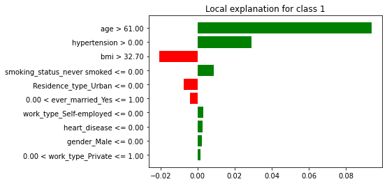

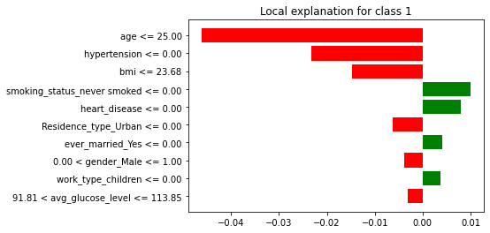

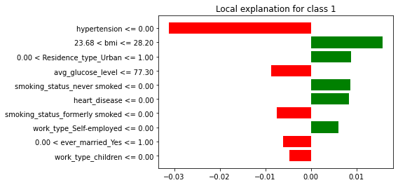

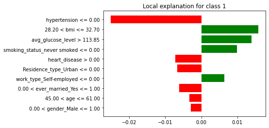

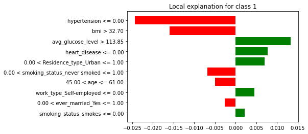

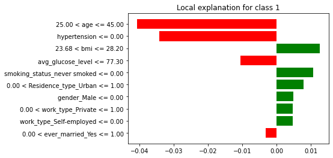

```python
for i in range(observations_data.shape[0]):
  explanation = explainer.predict_surrogate(observations_data.iloc[[i]])
  explanation.plot()
```